# Class 23

#### 23.7.3.2 Bayesian

Let’s whether there was a main effect of gender.

```r
# main effect of gender
fit.brm_polite %>%
  emmeans(specs = pairwise ~ gender) %>%
  pluck("contrasts")
```

```
NOTE: Results may be misleading due to involvement in interactions
```

```
 contrast estimate lower.HPD upper.HPD
 F - M         108      91.7       124

Results are averaged over the levels of: attitude
Point estimate displayed: median
HPD interval probability: 0.95
```

Let’s take a look what the full posterior distribution over this contrast looks like:

```
NOTE: Results may be misleading due to involvement in interactions
```

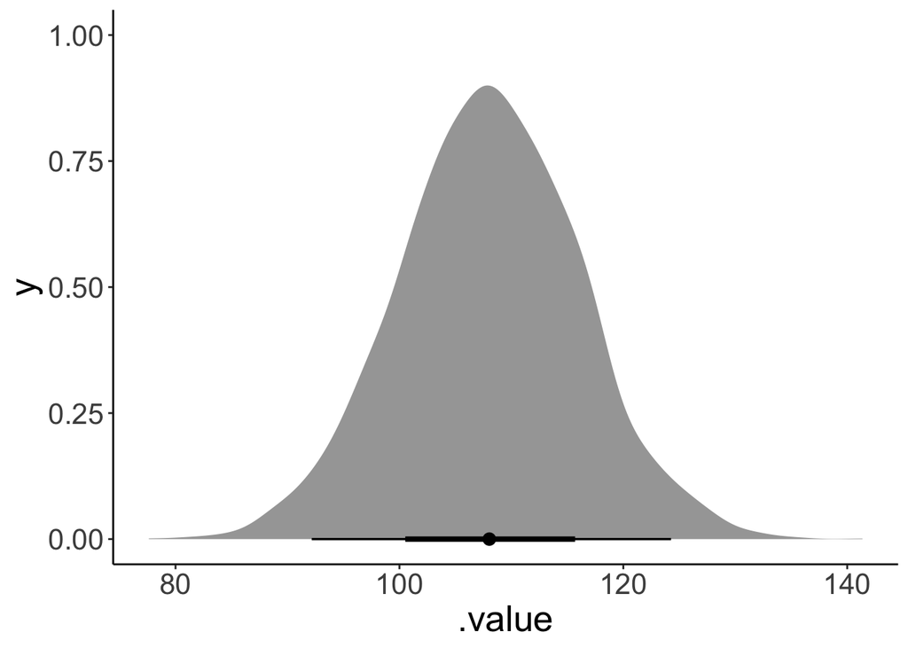

```r
fit.brm_polite %>%
  emmeans(specs = pairwise ~ gender) %>%
  pluck("contrasts") %>%
  gather_emmeans_draws() %>%
  ggplot(mapping = aes(x = .value)) +
  stat_halfeye()
```

Looks neat!

And let’s confirm that we really estimated the main effect here. Let’s fit a model that only has gender as a predictor, and then compare:

```r
fit.brm_polite_gender = brm(formula = pitch ~ 1 + gender,
                            data = df.politeness,
                            file = "cache/brm_polite_gender",
                            seed = 1)

# using the gather_emmeans_draws to get means rather than medians
fit.brm_polite %>%
  emmeans(spec = pairwise ~ gender) %>%
  pluck("contrasts") %>%
  gather_emmeans_draws() %>%
  mean_hdi()
```

```
NOTE: Results may be misleading due to involvement in interactions
```

```
# A tibble: 1 × 7
  contrast .value .lower .upper .width .point .interval
  <chr>     <dbl>  <dbl>  <dbl>  <dbl> <chr>  <chr>
1 F - M      108.   91.9   124.   0.95 mean   hdi
```

```r
fit.brm_polite_gender %>%
  fixef() %>%
  as_tibble(rownames = "term")
```

```
# A tibble: 2 × 5
  term      Estimate Est.Error  Q2.5 Q97.5
  <chr>        <dbl>     <dbl> <dbl> <dbl>
1 Intercept     247.      5.72  236. 258.
2 genderM      -108.      8.16 -124. -92.3
```

Yip, both of these methods give us the same result (the sign is flipped but that’s just because emmeans computed F-M, whereas the other method computed M-F)! Again, the `emmeans()` route is more convenient because we can more easily check for several main effects (and take a look at specific contrast, too).

```r
# main effect attitude
fit.brm_polite %>%
  emmeans(specs = pairwise ~ attitude) %>%
  pluck("contrasts")
```

```
NOTE: Results may be misleading due to involvement in interactions
```

```
 contrast  estimate lower.HPD upper.HPD
 inf - pol     19.8      5.16      35.9

Results are averaged over the levels of: gender
Point estimate displayed: median
HPD interval probability: 0.95
```

```r
# effect of attitude separately for each gender
fit.brm_polite %>%
  emmeans(specs = pairwise ~ attitude | gender) %>%
  pluck("contrasts")
```

```
gender = F:
 contrast  estimate lower.HPD upper.HPD
 inf - pol     27.9      5.96      49.5

gender = M:
 contrast  estimate lower.HPD upper.HPD
 inf - pol     12.0     -9.29      34.2

Point estimate displayed: median
HPD interval probability: 0.95
```

```r
# in case you want the means instead of medians
fit.brm_polite %>%
  emmeans(specs = pairwise ~ attitude | gender) %>%
  pluck("contrasts") %>%
  gather_emmeans_draws() %>%
  mean_hdi()
```

```
# A tibble: 2 × 8
  contrast  gender .value .lower .upper .width .point .interval
  <fct>     <fct>   <dbl>  <dbl>  <dbl>  <dbl> <chr>  <chr>
1 inf - pol F        27.8   5.96   49.5   0.95 mean   hdi
2 inf - pol M        11.9  -9.29   34.2   0.95 mean   hdi
```

Here is a way to visualize the contrasts:

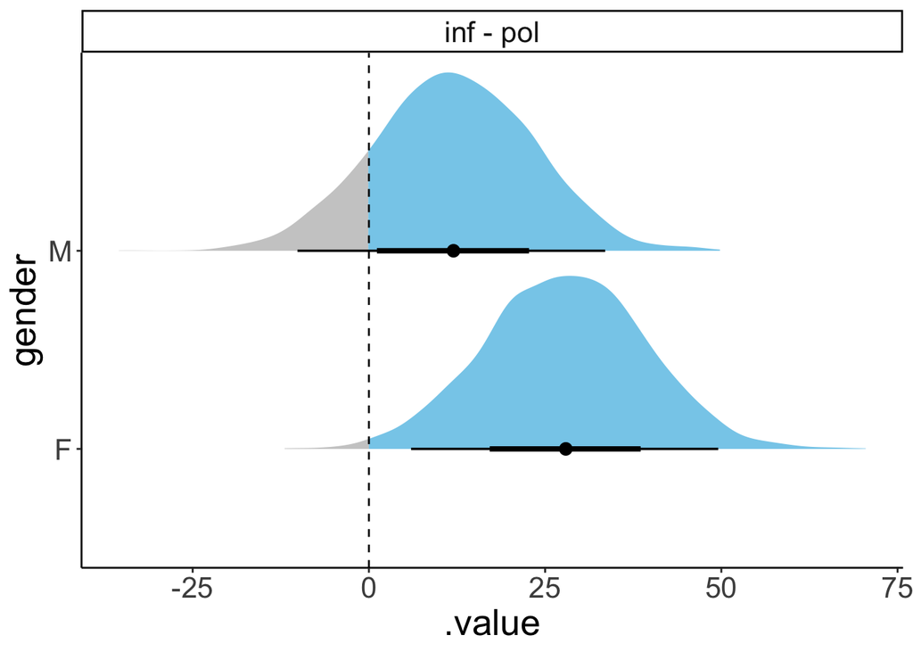

```r
fit.brm_polite %>%
  emmeans(specs = pairwise ~ attitude | gender) %>%
  pluck("contrasts") %>%
  gather_emmeans_draws() %>%
  ggplot(aes(x = .value,
             y = gender,
             fill = after_stat(x > 0))) +
  facet_wrap(~ contrast) +
  stat_halfeye(show.legend = F) +
  geom_vline(xintercept = 0,
             linetype = 2) +
  scale_fill_manual(values = c("gray80", "skyblue"))
```

Here is one way to check whether there was an interaction between attitude and gender (see [this vignette](https://cran.r-project.org/web/packages/emmeans/vignettes/interactions.html) for more info).

```r
fit.brm_polite %>%
  emmeans(pairwise ~ attitude | gender) %>%
  pluck("emmeans") %>%
  contrast(interaction = c("consec"),
           by = NULL)
```

```
 attitude_consec gender_consec estimate lower.HPD upper.HPD
 pol - inf       M - F             16.1     -15.1      47.2

Point estimate displayed: median
HPD interval probability: 0.95
```

## 23.8 Additional resources

- [Bayesian regression: Theory & Practice](https://michael-franke.github.io/Bayesian-Regression/)
- [Tutorial on visualizing brms posteriors with tidybayes](https://mjskay.github.io/tidybayes/articles/tidy-brms.html)
- [Hypothetical outcome plots](https://mucollective.northwestern.edu/files/2018-HOPsTrends-InfoVis.pdf)
- [Visual MCMC diagnostics](https://cran.r-project.org/web/packages/bayesplot/vignettes/visual-mcmc-diagnostics.html#general-mcmc-diagnostics)
- [Visualization of different MCMC algorithms](https://chi-feng.github.io/mcmc-demo/)
- [Article describing the different inference algorithms](https://elevanth.org/blog/2017/11/28/build-a-better-markov-chain/)